# Best books by century

Marian Nehrebecki, Aleksander Partyga, Magdalena Sobala

07 June, 2022

## **Century 15**

### Overview

(From the [Goodreads](https://www.goodreads.com)) Goodreads.com is the world’s largest site for readers and book recommendations. The mission of Goodreads is to help people find and share books they love.

The users can rate their favourite books, create lists and share their opinions with their friends. The website also provides extensive information on books from all genres and centuries; it also provides the users with rankings, available by different parameters. The rankings that are of interest to us, are the rating by the century. Below you can find a short summary of each century’s best books.

### A few things we can do on Goodreads

> - See what books our friends are reading.
> - Track the books we are reading, have read, and want to read.
> - Check out our personalized book recommendations. The recommendation engine analyzes 20 billion data points to give suggestions tailored to our literary tastes.
> - Find out if a book is a good fit for us from our community’s reviews.

# Summary of the Best books in Century 15

*Goodreads* provides its users with information on 69 books from **Century 15** that have been published by Author/Authors from **Thomas Malory** to **Luigi Pulci**.

The book can be found under the following link: “https://www.goodreads.com/book/show/672875.Le_Morte_d_Arthur”

## Visualisations:

### Books that were rated the most times in Century 15

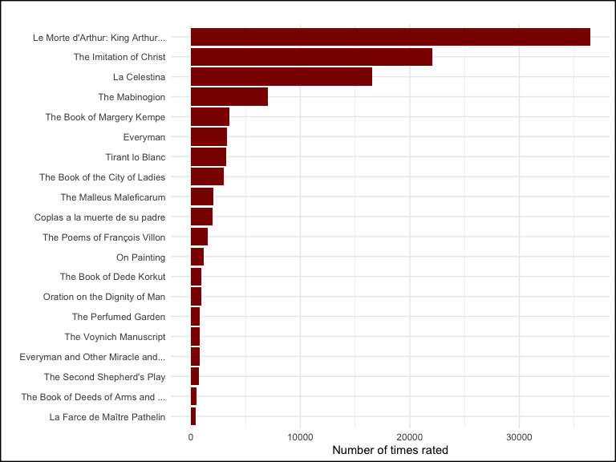

**Summary:**

- The book that was rated the most in Century 15 is **Le Morte d’Arthur: King Arthur and the Legends of the Round Table**, and the number of votes is **36474**.
- The average number of voted for a book from Century 15 is equal **1647.3**.

### Books with the highest scores in Century 15

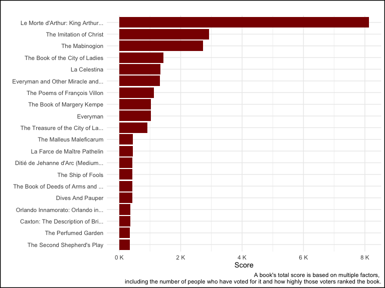

**Summary:**

- The maximum score for a book in Century 15 is **8130** for the book: **Le Morte d’Arthur: King Arthur and the Legends of the Round Table**.
- The average score of all books in Century 15 is **511**.
- The minimum score for a book in Century 15 is **86** for the book: **Morgante: The Epic Adventures of Orlando and His Giant Friend Morgante**.

### Most prolific authors in Century 15

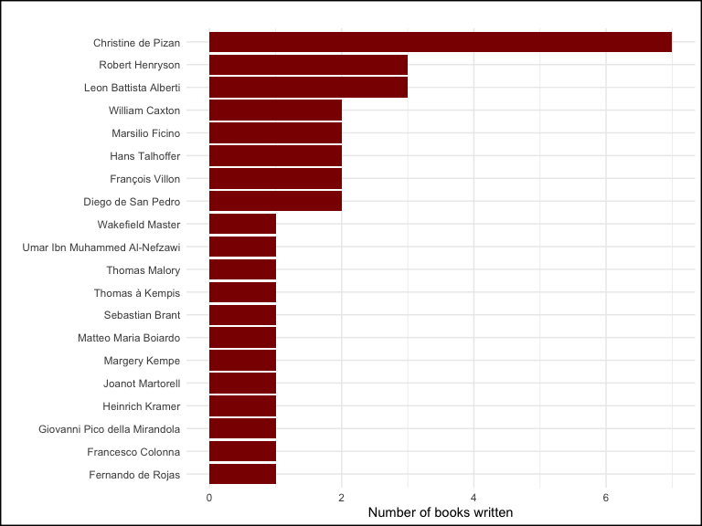

**Summary:**

- The most prolific author in Century 15 is **Christine de Pizan**.

## List of books with above average rating in Century 15

The number of books with the above average rating in Century 15 is **36** out of all **69** Century 15 books. The below table displays the top 10 results.

| Century | Title | Author | website |
| --- | --- | --- | --- |
| 15th | The Imitation of Christ | Thomas à Kempis | https://www.goodreads.com/book/show/851393.The_Imitation_of_Christ |
| 15th | The Book of the City of Ladies | Christine de Pizan | https://www.goodreads.com/book/show/89049.The_Book_of_the_City_of_Ladies |
| 15th | The Poems of François Villon | François Villon | https://www.goodreads.com/book/show/97393.The_Poems_of_Fran_ois_Villon |
| 15th | Orlando Innamorato: Orlando in Love | Matteo Maria Boiardo | https://www.goodreads.com/book/show/756484.Orlando_Innamorato |
| 15th | Hypnerotomachia Poliphili: The Strife of Love in a Dream | Francesco Colonna | https://www.goodreads.com/book/show/790952.Hypnerotomachia_Poliphili |
| 15th | Talhoffers Fechtbuch (Gothaer Codex) Aus Dem Jahre 1443 … | Hans Talhoffer | https://www.goodreads.com/book/show/9556019-talhoffers-fechtbuch-gothaer-codex-aus-dem-jahre-1443 |
| 15th | Coplas a la muerte de su padre | Jorge Manrique | https://www.goodreads.com/book/show/865225.Coplas_a_la_muerte_de_su_padre |
| 15th | The Très Riches Heures of Jean, Duke of Berry | Jean Longnon | https://www.goodreads.com/book/show/936404.The_Tr_s_Riches_Heures_of_Jean_Duke_of_Berry |
| 15th | On Painting | Leon Battista Alberti | https://www.goodreads.com/book/show/814670.On_Painting |
| 15th | Momus | Leon Battista Alberti | https://www.goodreads.com/book/show/814671.Momus |

### References:

https://www.goodreads.com